# HADS

2020年4月9日

## Group Introduction

**Name:**

410578043 Haytham Lee 410578068 Wei Chieh Chen

## Data Source and Introduction

**Name:**

Housing Affordability Data System

**Introduction:**

住房負擔能力數據系統（HADS）是一套住房單位數據集，透過住房單位的地區收入中位數、貧困水平收入和公市場租金，衡量單位的負擔能力和住戶成本。這些數據集的目是為住房分析師提供長期負擔能力和的一致措施。

**Source:**

United States Department of Housing and Urban Development (HUD)

**URL:**

https://catalog.data.gov/dataset/housing-affordability-data-system-hads.

## Variable Description

[output not shown]

## Data Appearance

| AGE1 | LMED | FMR | L30 | L50 | L80 | IPOV | BEDRMS | BUILT | TENURE | NUNITS | ROOMS | WEIGHT | PER | ZINC2 | ZSMHC | UTILITY | OTHERCOST | COST06 | COST12 | COST08 | COSTMED | TOTSAL | GLMED | GL30 | GL50 | GL80 | APLMED | ABL30 | ABL50 | … |
| --- | --- | --- | --- | --- | --- | --- | --- | --- | --- | --- | --- | --- | --- | --- | --- | --- | --- | --- | --- | --- | --- | --- | --- | --- | --- | --- | --- | --- | --- | --- |
| 53 | 58768 | 931 | 16066 | 26760 | 42811 | 18070 | 4 | 1990 | 1 | 1 | 7 | 3792.611 | 3 | 189961 | 972 | 355.0000 | 108.33333 | 2124.8220 | 3090.2117 | 2426.8036 | 1915.8753 | 190000 | 58768 | 16066 | 26760 | 42811 | 52891.2 | 20707.29 | 34490.67 | … |
| 78 | 63429 | 969 | 13400 | 22332 | 35706 | 11067 | 3 | 2005 | 1 | 1 | 5 | 2713.278 | 1 | 72000 | 605 | 158.6667 | 113.25000 | 1335.2694 | 1953.1188 | 1528.5377 | 1201.5435 | 0 | 63429 | 13400 | 22332 | 35706 | 44400.3 | 19908.57 | 33178.97 | … |
| 34 | 49875 | 727 | 12683 | 21101 | 33764 | 15946 | 2 | 1980 | 2 | 8 | 4 | 2502.538 | 2 | 8820 | 464 | 64.0000 | 0.00000 | 464.0000 | 464.0000 | 464.0000 | 464.0000 | 0 | 49875 | 12683 | 21101 | 33764 | 39900.0 | 14268.38 | 23738.62 | … |
| 19 | 58019 | 649 | 14121 | 23526 | 37637 | 15492 | 2 | 1985 | 2 | 4 | 4 | 1847.146 | 2 | 3574 | 136 | 81.0000 | 0.00000 | 136.0000 | 136.0000 | 136.0000 | 136.0000 | 3600 | 58019 | 14121 | 23526 | 37637 | 46415.2 | 15886.12 | 26466.75 | … |
| 72 | 56613 | 868 | 13931 | 23192 | 37100 | 13948 | 2 | 1980 | 1 | 1 | 5 | 2901.843 | 2 | 25636 | 383 | 211.8333 | 82.41667 | 693.0073 | 924.7008 | 765.4829 | 642.8601 | 0 | 56613 | 13931 | 23192 | 37100 | 45290.4 | 15672.38 | 26091.00 | … |
| 70 | 55926 | 1178 | 11742 | 19559 | 31277 | 11080 | 4 | 2005 | 1 | 1 | 7 | 2053.071 | 1 | 41682 | 616 | 241.0000 | 80.00000 | 1384.3528 | 2002.2021 | 1577.6210 | 1250.6268 | 0 | 55926 | 11742 | 19559 | 31277 | 39148.2 | 19458.17 | 32412.06 | … |

## Summary of Variables

**Categorical Variables**

|  | level | Overall |
| --- | --- | --- |
| n |  | 24001 |
| BEDRMS (%) | 0 | 196 ( 0.8) |
|  | 1 | 3527 (14.7) |
|  | 2 | 5796 (24.1) |
|  | 3 | 9318 (38.8) |
|  | 4 | 4073 (17.0) |
|  | 5 | 922 ( 3.8) |
|  | 6 | 152 ( 0.6) |
|  | 7 | 17 ( 0.1) |
| BUILT (%) | 1919 | 1387 ( 5.8) |
|  | 1920 | 868 ( 3.6) |
|  | 1930 | 935 ( 3.9) |
|  | 1940 | 1262 ( 5.3) |
|  | 1950 | 2372 ( 9.9) |
|  | 1960 | 2573 (10.7) |
|  | 1970 | 1914 ( 8.0) |
|  | 1975 | 2145 ( 8.9) |
|  | 1980 | 1298 ( 5.4) |
|  | 1985 | 1243 ( 5.2) |
|  | 1990 | 826 ( 3.4) |
|  | 1995 | 3768 (15.7) |
|  | 2000 | 655 ( 2.7) |
|  | 2001 | 606 ( 2.5) |
|  | 2002 | 527 ( 2.2) |
|  | 2003 | 352 ( 1.5) |
|  | 2004 | 207 ( 0.9) |
|  | 2005 | 209 ( 0.9) |
|  | 2006 | 197 ( 0.8) |
|  | 2007 | 197 ( 0.8) |
|  | 2008 | 146 ( 0.6) |
|  | 2009 | 137 ( 0.6) |
|  | 2010 | 120 ( 0.5) |
|  | 2011 | 40 ( 0.2) |
|  | 2012 | 12 ( 0.0) |
|  | 2013 | 5 ( 0.0) |
| TENURE (%) | 1 | 14076 (58.6) |
|  | 2 | 9570 (39.9) |
|  | 3 | 355 ( 1.5) |
| FMTZADEQ (%) | 1 Adequate | 22787 (94.9) |
|  | 2 Moderately Inadequate | 796 ( 3.3) |
|  | 3 Severely Indadequate | 418 ( 1.7) |
| FMTMETRO3 (%) | Central City | 7692 (32.0) |
|  | Nonmetro | 4321 (18.0) |
|  | Suburb | 11988 (49.9) |
| FMTSTRUCTURETYPE (%) | 1 Single Family | 15700 (65.4) |
|  | 2 2-4 units | 2232 ( 9.3) |
|  | 3 5-19 units | 2714 (11.3) |
|  | 4 20-49 units | 965 ( 4.0) |
|  | 5 50+ units | 1632 ( 6.8) |
|  | 6 Mobile Home | 758 ( 3.2) |
| FMTBEDRMS (%) | 0 Studio | 196 ( 0.8) |
|  | 1 1BR | 3527 (14.7) |
|  | 2 2BR | 5796 (24.1) |
|  | 3 3BR | 9318 (38.8) |
|  | 4 4BR+ | 5164 (21.5) |
| FMTOWNRENT (%) | 1 Owner | 14076 (58.6) |
|  | 2 Renter | 9925 (41.4) |
| FMTREGION (%) | Midwest | 6481 (27.0) |
|  | Northeast | 5291 (22.0) |
|  | South | 7941 (33.1) |
|  | West | 4288 (17.9) |

**Continuous Variables**

|  | n | miss | p.miss | mean | sd | median | min | max |
| --- | --- | --- | --- | --- | --- | --- | --- | --- |
| AGE1 | 24001.0000000 | 0.0000000 | 0.0000000 | 51.8511312 | 17.3338002 | 51.0000000 | 15.0000000 | 93.0000000 |
| LMED | 24001.0000000 | 0.0000000 | 0.0000000 | 67349.0210408 | 11984.3200370 | 64165.0000000 | 38500.0000000 | 115300.0000000 |
| FMR | 24001.0000000 | 0.0000000 | 0.0000000 | 1156.2721553 | 393.0993353 | 1094.0000000 | 394.0000000 | 3511.0000000 |
| L30 | 24001.0000000 | 0.0000000 | 0.0000000 | 17699.3099038 | 4348.8981621 | 16929.0000000 | 10257.0000000 | 42550.0000000 |
| L50 | 24001.0000000 | 0.0000000 | 0.0000000 | 29489.5703929 | 7252.1625723 | 28178.0000000 | 17057.0000000 | 70850.0000000 |
| L80 | 24001.0000000 | 0.0000000 | 0.0000000 | 46300.0185826 | 10493.9465046 | 44618.0000000 | 27307.0000000 | 111450.0000000 |
| IPOV | 24001.0000000 | 0.0000000 | 0.0000000 | 17225.2121162 | 5943.7884452 | 15470.0000000 | 11057.0000000 | 51487.0000000 |
| NUNITS | 24001.0000000 | 0.0000000 | 0.0000000 | 13.7102204 | 50.0745226 | 1.0000000 | 1.0000000 | 998.0000000 |
| ROOMS | 24001.0000000 | 0.0000000 | 0.0000000 | 5.7294279 | 1.9523800 | 6.0000000 | 1.0000000 | 15.0000000 |
| WEIGHT | 24001.0000000 | 0.0000000 | 0.0000000 | 1857.3036884 | 1165.6212681 | 1977.7314510 | 7.5344266 | 22743.7197500 |
| PER | 24001.0000000 | 0.0000000 | 0.0000000 | 2.4826466 | 1.4597806 | 2.0000000 | 1.0000000 | 20.0000000 |
| ZINC2 | 24001.0000000 | 0.0000000 | 0.0000000 | 66738.8465897 | 77048.4827101 | 44974.0000000 | -65.0000000 | 831203.0000000 |
| ZSMHC | 24001.0000000 | 0.0000000 | 0.0000000 | 1142.1425774 | 982.2345168 | 898.0000000 | 0.0000000 | 9726.0000000 |
| UTILITY | 24001.0000000 | 0.0000000 | 0.0000000 | 187.1549102 | 128.8116329 | 172.0000000 | 0.0000000 | 1613.0000000 |
| OTHERCOST | 24001.0000000 | 0.0000000 | 0.0000000 | 70.5482133 | 143.9698052 | 33.7500000 | 0.0000000 | 6676.0000000 |
| COST06 | 24001.0000000 | 0.0000000 | 0.0000000 | 1538.9264831 | 1667.4391447 | 1120.0574480 | 0.0000000 | 18768.7225800 |
| COST12 | 24001.0000000 | 0.0000000 | 0.0000000 | 2109.0956718 | 2588.1640323 | 1376.0000000 | 0.0000000 | 28499.8503700 |
| COST08 | 24001.0000000 | 0.0000000 | 0.0000000 | 1717.2799669 | 1952.0134969 | 1205.4657400 | 0.0000000 | 21812.6972000 |
| COSTMED | 24001.0000000 | 0.0000000 | 0.0000000 | 1415.5203655 | 1473.7488239 | 1057.0000000 | 0.0000000 | 16662.5394900 |
| TOTSAL | 24001.0000000 | 0.0000000 | 0.0000000 | 48904.0282905 | 67060.3119665 | 27360.0000000 | 0.0000000 | 692686.0000000 |
| GLMED | 24001.0000000 | 0.0000000 | 0.0000000 | 67349.0210408 | 11984.3200370 | 64165.0000000 | 38500.0000000 | 115300.0000000 |
| GL30 | 24001.0000000 | 0.0000000 | 0.0000000 | 17699.3099038 | 4348.8981621 | 16929.0000000 | 10257.0000000 | 42550.0000000 |
| GL50 | 24001.0000000 | 0.0000000 | 0.0000000 | 29489.5703929 | 7252.1625723 | 28178.0000000 | 17057.0000000 | 70850.0000000 |
| GL80 | 24001.0000000 | 0.0000000 | 0.0000000 | 46300.0185826 | 10493.9465046 | 44618.0000000 | 27307.0000000 | 111450.0000000 |
| APLMED | 24001.0000000 | 0.0000000 | 0.0000000 | 56976.7818283 | 14167.6571791 | 54296.2000000 | 26950.0000000 | 217448.1600000 |
| ABL30 | 24001.0000000 | 0.0000000 | 0.0000000 | 20743.2448445 | 4688.6338571 | 19959.3333300 | 10453.0000000 | 48302.2222200 |
| ABL50 | 24001.0000000 | 0.0000000 | 0.0000000 | 34560.7478205 | 7818.2759165 | 33239.4400000 | 17386.2500000 | 80560.0000000 |
| ABL80 | 24001.0000000 | 0.0000000 | 0.0000000 | 54260.8431985 | 11080.9696869 | 53011.1111100 | 27827.0000000 | 113296.2963000 |
| ABLMED | 24001.0000000 | 0.0000000 | 0.0000000 | 66867.0051023 | 15679.3457711 | 64743.0000000 | 28875.0000000 | 160968.0000000 |
| BURDEN | 24001.0000000 | 0.0000000 | 0.0000000 | 2.9585840 | 116.9413114 | 0.2355009 | -1.0000000 | 12936.0000000 |
| INCRELAMIPCT | 24001.0000000 | 0.0000000 | 0.0000000 | 115.6303586 | 128.2526076 | 82.5707545 | -0.1113014 | 1554.2349140 |
| INCRELPOVPCT | 24001.0000000 | 0.0000000 | 0.0000000 | 387.7365669 | 439.7519250 | 269.8048220 | -0.2219945 | 4726.1683450 |
| INCRELFMRPCT | 24001.0000000 | 0.0000000 | 0.0000000 | 140.4402846 | 147.5980764 | 101.3220721 | -0.1937407 | 1718.6963780 |
| COST06RELAMIPCT | 24001.0000000 | 0.0000000 | 0.0000000 | 87.7660998 | 84.2808708 | 69.3199473 | 0.0000000 | 1475.2851560 |
| COST06RELPOVPCT | 24001.0000000 | 0.0000000 | 0.0000000 | 374.8950424 | 418.9567315 | 268.8879634 | 0.0000000 | 6416.6567670 |
| COST06RELFMRPCT | 24001.0000000 | 0.0000000 | 0.0000000 | 126.0748027 | 110.4747259 | 104.1446675 | 0.0000000 | 2146.3756390 |
| COST08RELAMIPCT | 24001.0000000 | 0.0000000 | 0.0000000 | 97.3909177 | 98.2659717 | 74.6608502 | 0.0000000 | 1732.9761300 |
| COST08RELPOVPCT | 24001.0000000 | 0.0000000 | 0.0000000 | 417.7270385 | 488.9790559 | 288.5431400 | 0.0000000 | 7515.5645740 |
| COST08RELFMRPCT | 24001.0000000 | 0.0000000 | 0.0000000 | 139.6045669 | 128.6576809 | 111.4002608 | 0.0000000 | 2529.7477590 |
| COST12RELAMIPCT | 24001.0000000 | 0.0000000 | 0.0000000 | 118.5351911 | 129.9234703 | 85.1966667 | 0.0000000 | 2299.0843340 |
| COST12RELPOVPCT | 24001.0000000 | 0.0000000 | 0.0000000 | 511.8224740 | 645.9976965 | 331.2217195 | 0.0000000 | 9929.6992890 |
| COST12RELFMRPCT | 24001.0000000 | 0.0000000 | 0.0000000 | 169.3274185 | 170.1218574 | 126.3029054 | 0.0000000 | 3371.9584840 |
| COSTMedRELAMIPCT | 24001.0000000 | 0.0000000 | 0.0000000 | 81.1065079 | 74.8740866 | 65.4613837 | 0.0000000 | 1296.9839430 |
| COSTMedRELPOVPCT | 24001.0000000 | 0.0000000 | 0.0000000 | 345.2587817 | 371.4307005 | 255.1848836 | 0.0000000 | 5656.3018630 |
| COSTMedRELFMRPCT | 24001.0000000 | 0.0000000 | 0.0000000 | 116.7133053 | 98.3306722 | 98.7075929 | 0.0000000 | 1881.1132860 |

**Response Variable to Be Predicted**

|  | n | miss | p.miss | mean | sd | median | min | max |
| --- | --- | --- | --- | --- | --- | --- | --- | --- |
| ZINC2 | 24001.00 | 0.00 | 0.00 | 66738.85 | 77048.48 | 44974.00 | -65.00 | 831203.00 |

## Research Problem

Predict the affordability of housing

## Missing Values

missing at random, delete the variable.

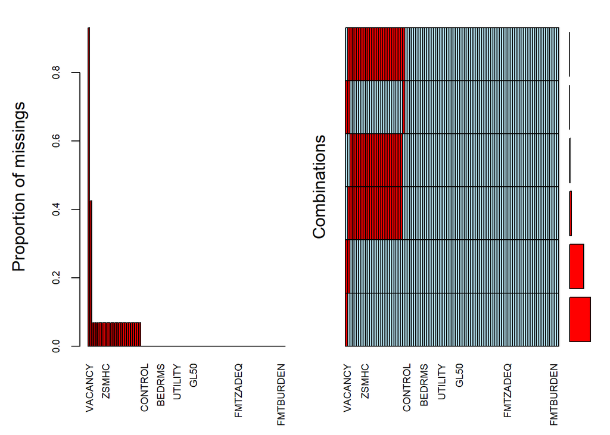

## Exploratory Data Analysis

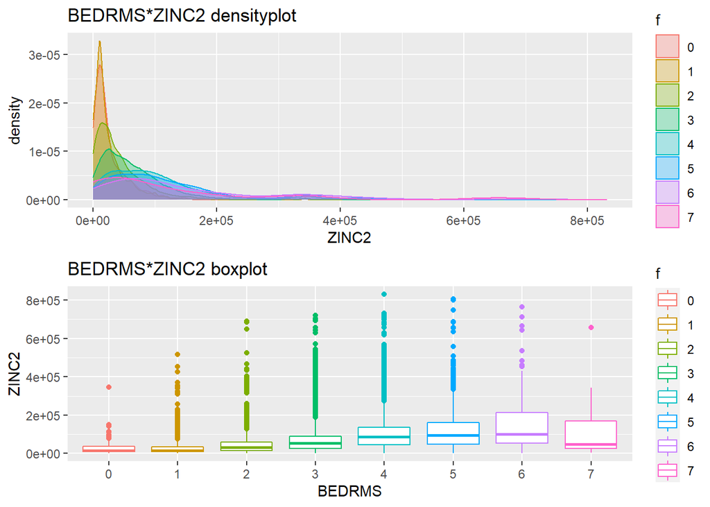

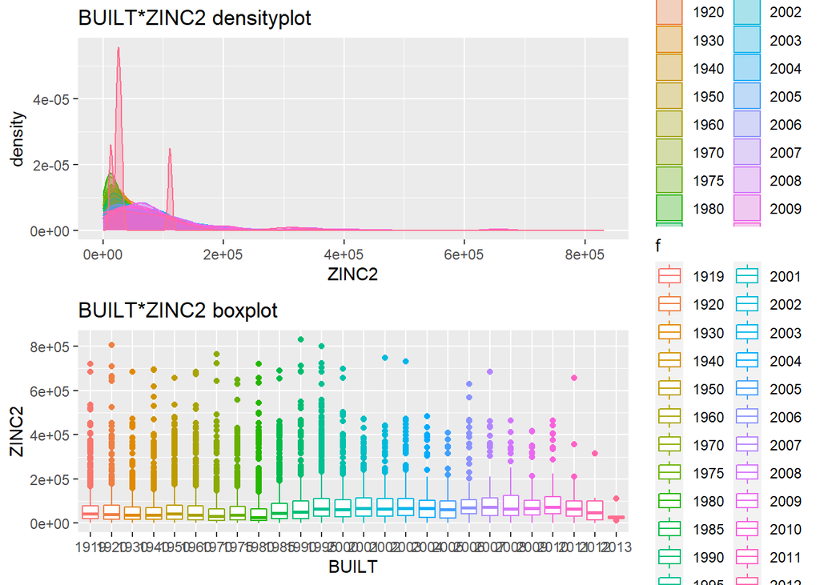

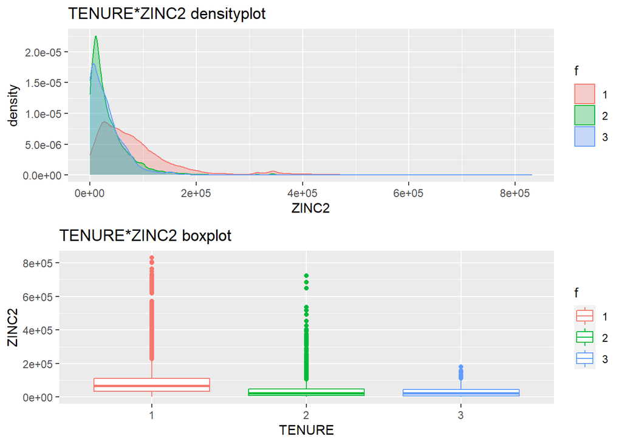

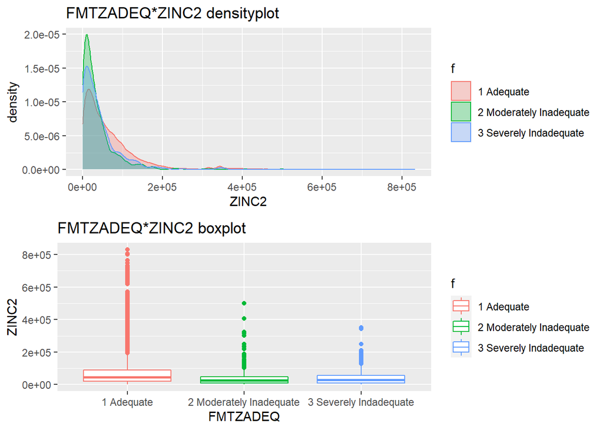

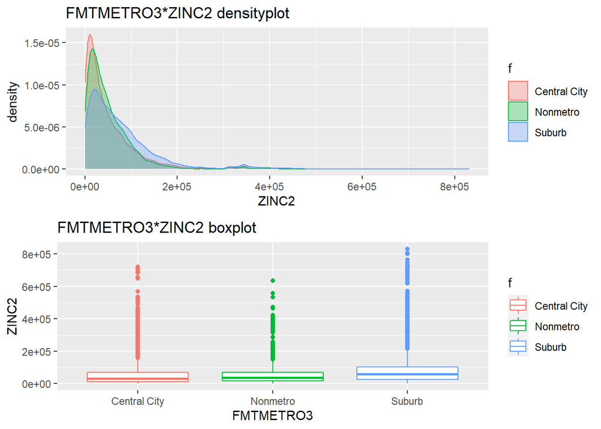

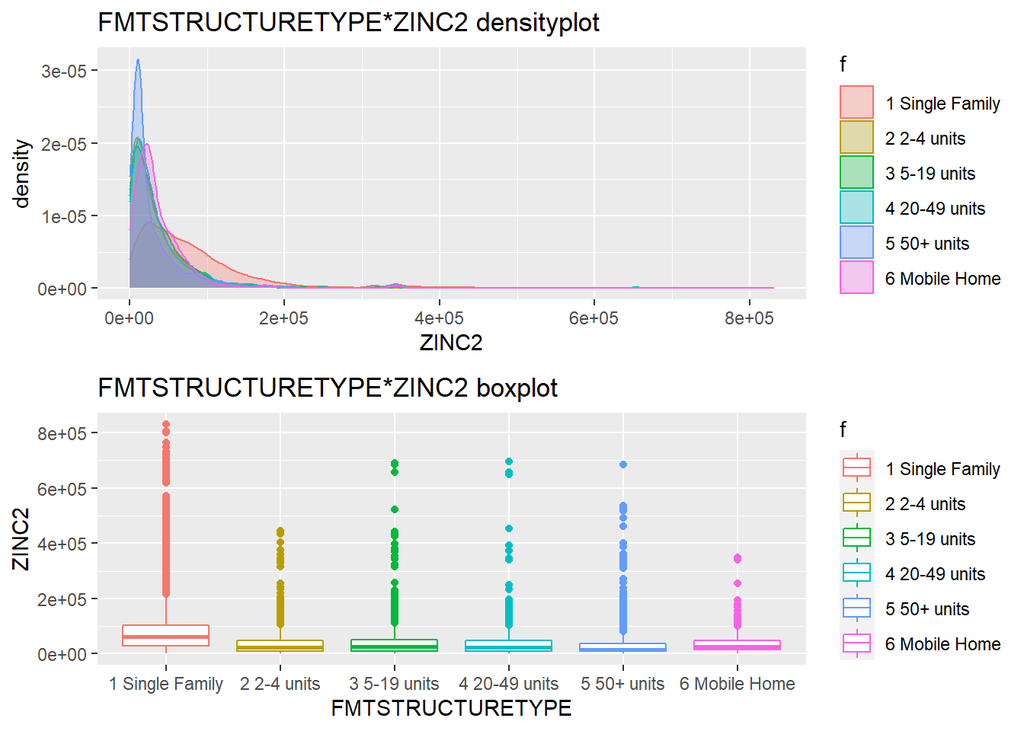

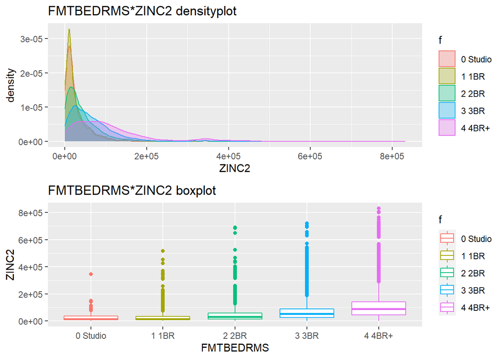

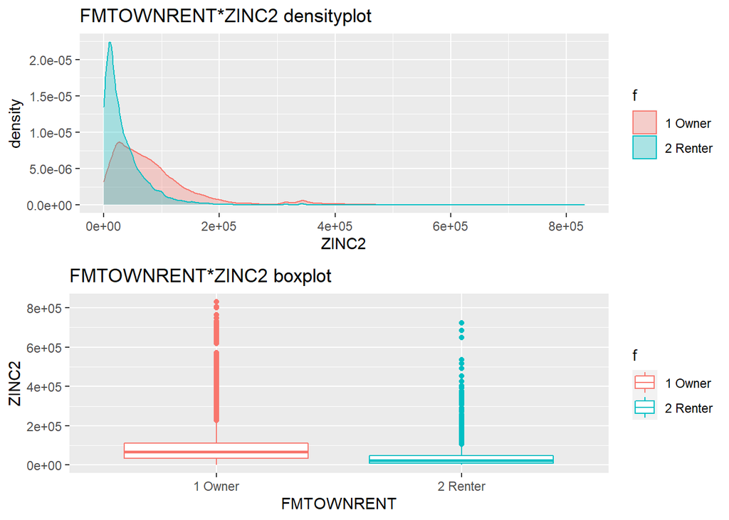

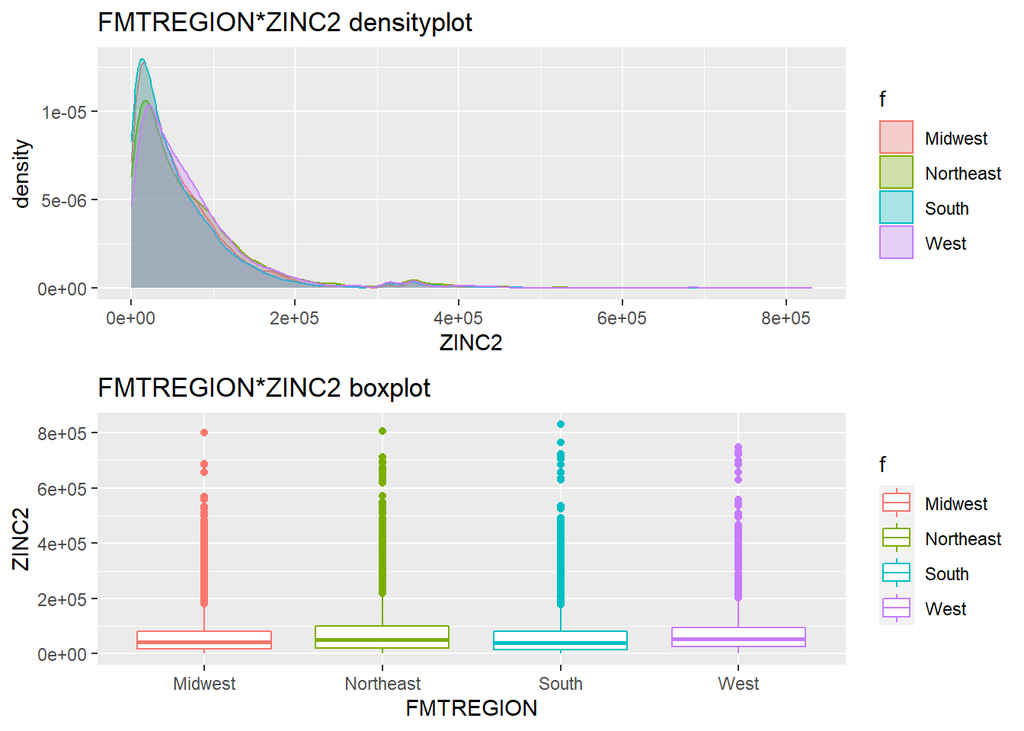

從圖形中我們可以發現，房間數越多，通常其家庭收入亦越多，但在房間數大於5後，反而會有平均收入下降的趨勢，離群值也隨著房間數增加，在大於5的房間之後離群值數量也有下降，數值也降低，房東與承租租者狀態分數越高，家庭收入卻越少，離群值的數量與數值也隨分數增加而下降，不同的普查地區出現的家庭收入分布接近一致，不過，郊區的家庭收入亦較市中心也比其他2者高，適當的家戶收入分佈較不適當的家戶高，建物的規模越大，家戶收入卻越低，單位臥室數分級數值越高，家戶收入也越高，自有住宅者的家戶收入也比租屋者高

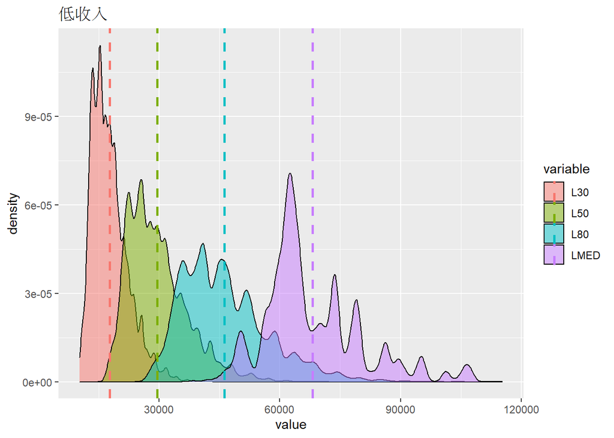

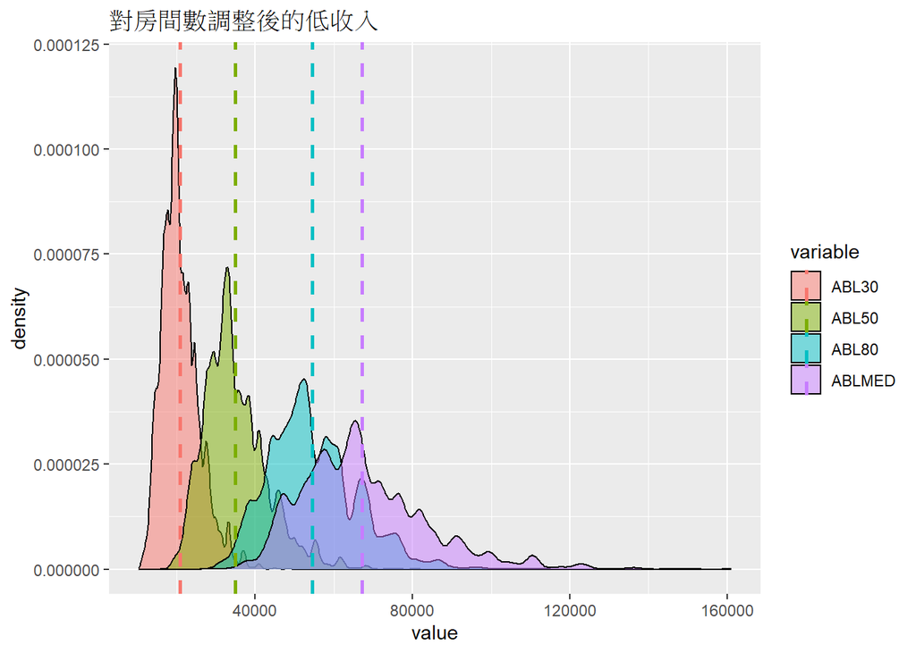

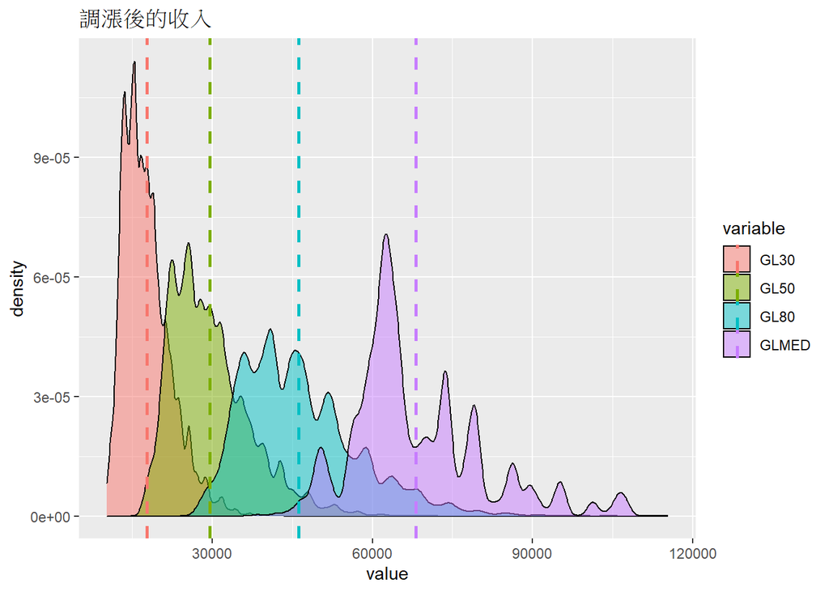

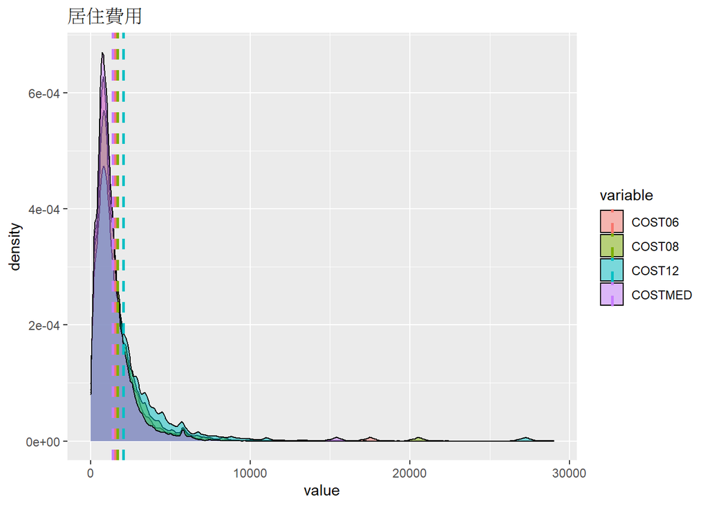

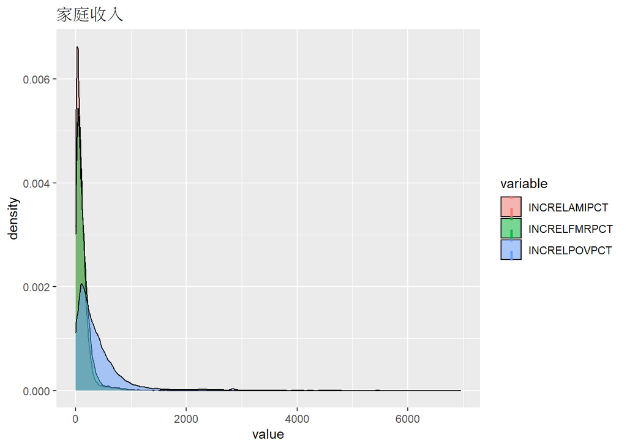

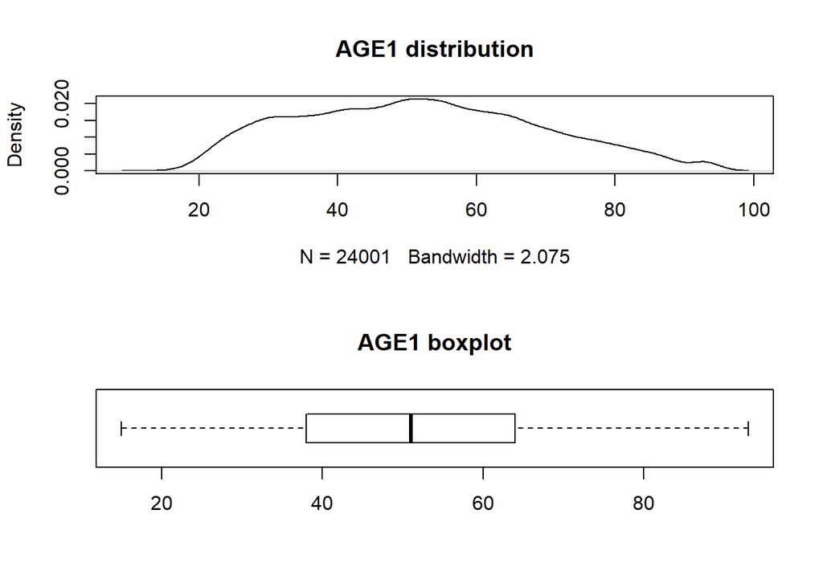

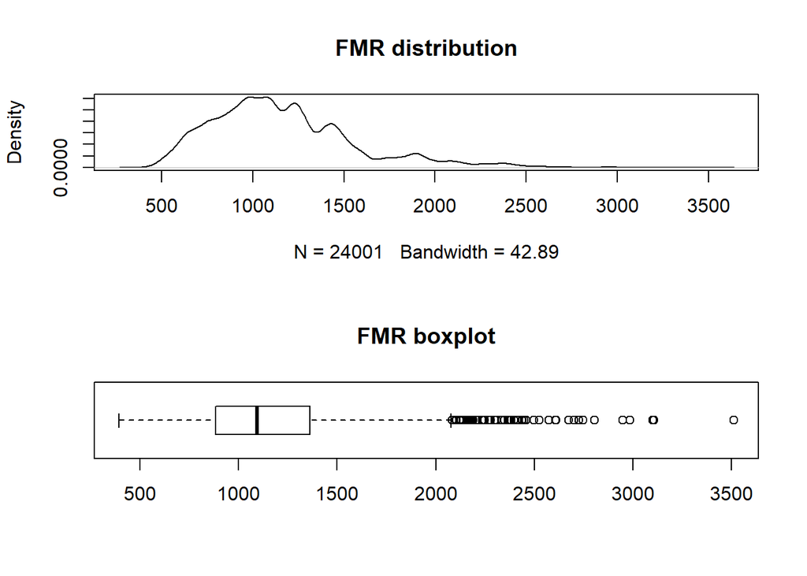

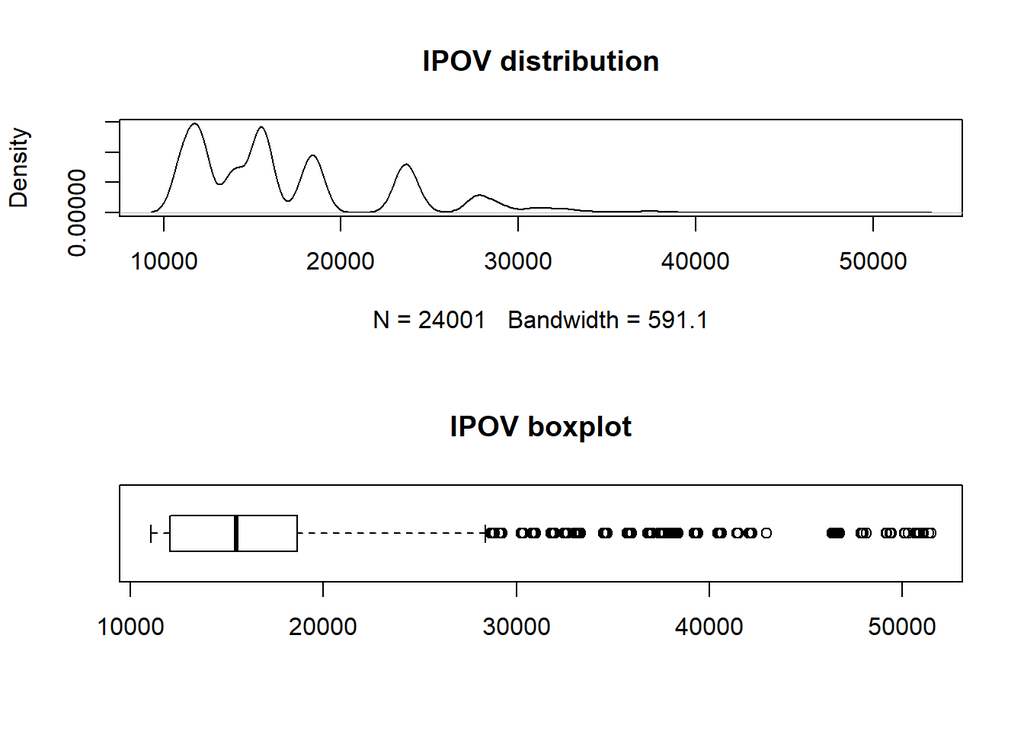

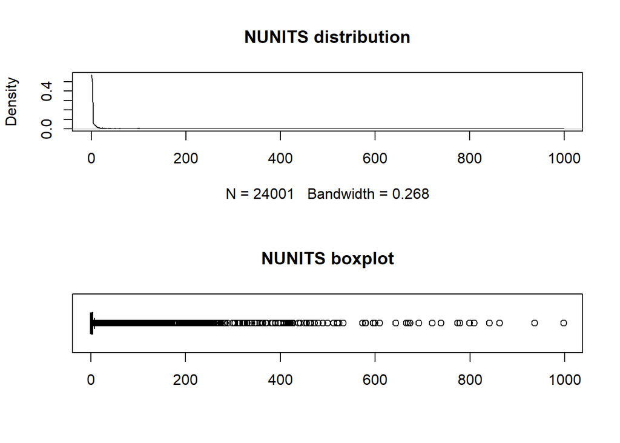

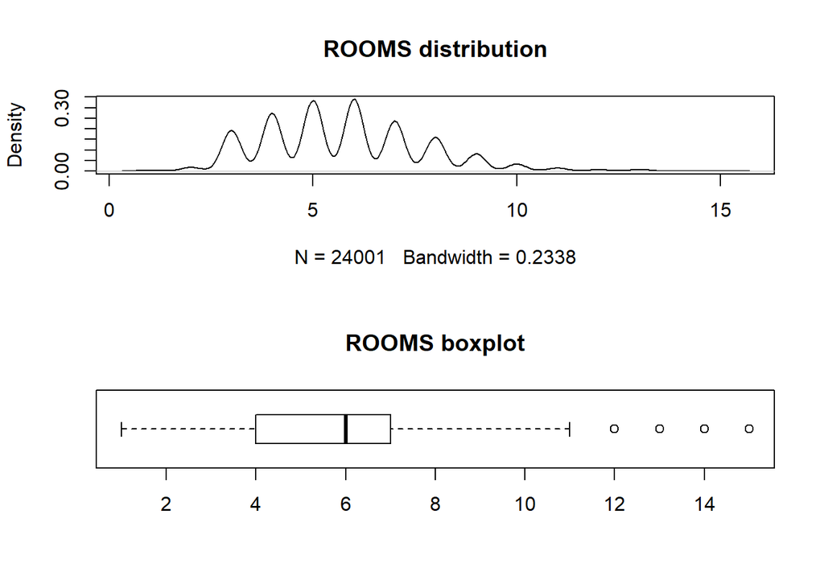

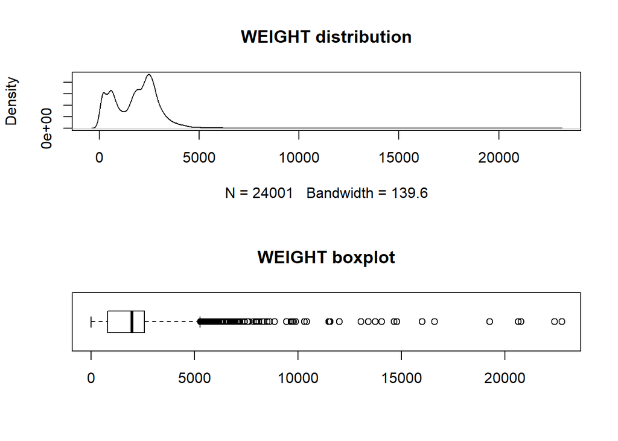

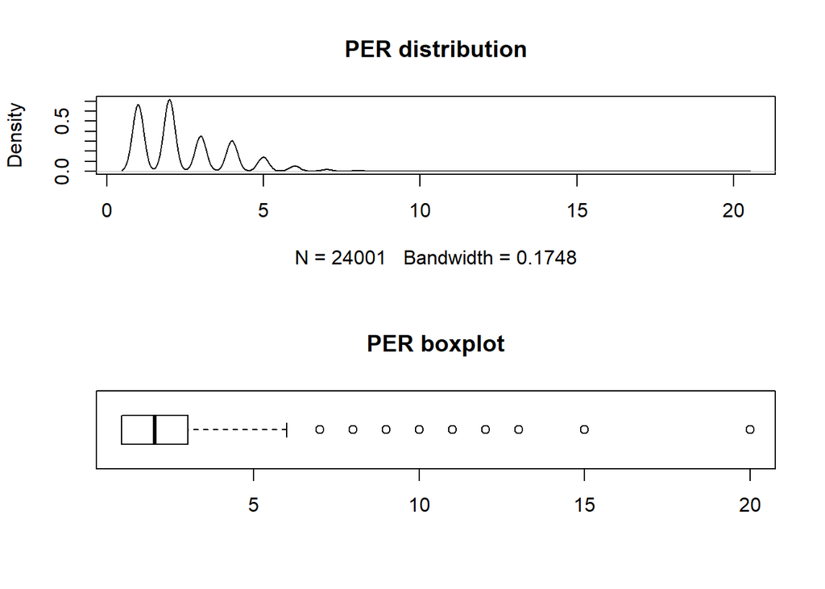

[7 more figures not shown]

```
##              x  Freq     prop
## 1 Central City 21493 33.30441
## 2     Nonmetro 11255 17.44015
## 3       Suburb 31787 49.25544
```

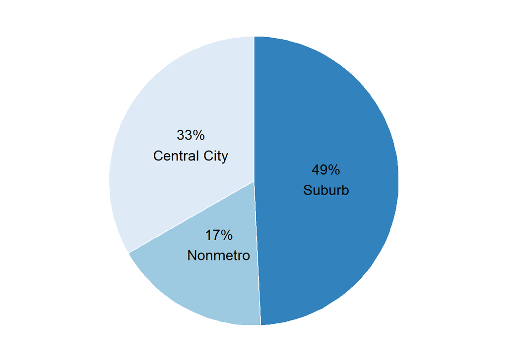

```
##           x  Freq     prop
## 1   Midwest 17400 26.96211
## 2 Northeast 16519 25.59696
## 3     South 19260 29.84427
## 4      West 11356 17.59665
```

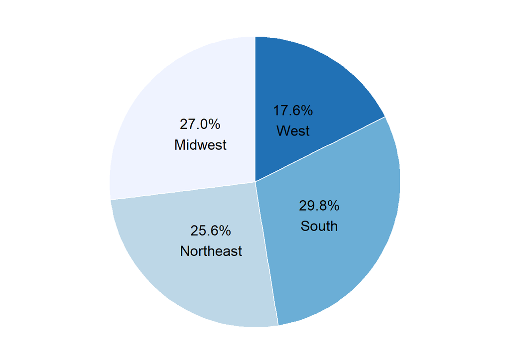

```
##                 x  Freq      prop
## 1               .  4438  6.876889
## 2 1 Less than 30% 36771 56.978384
## 3    2 30% to 50% 11295 17.502131
## 4   3 50% or More 10823 16.770745
## 5     4 No Income  1208  1.871852
```

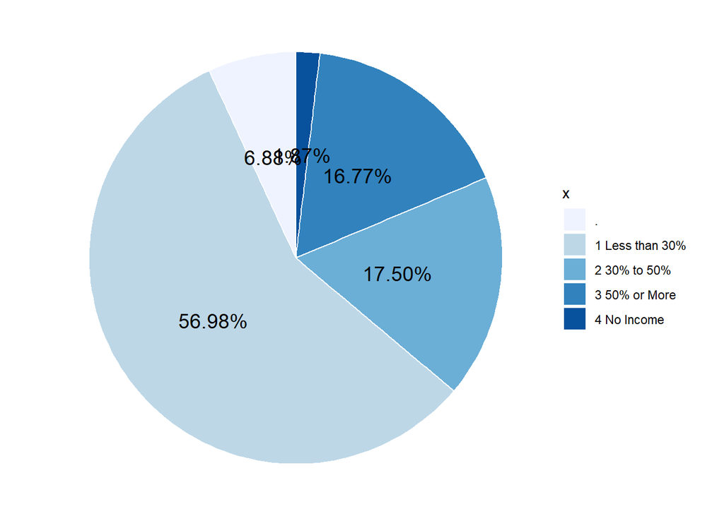

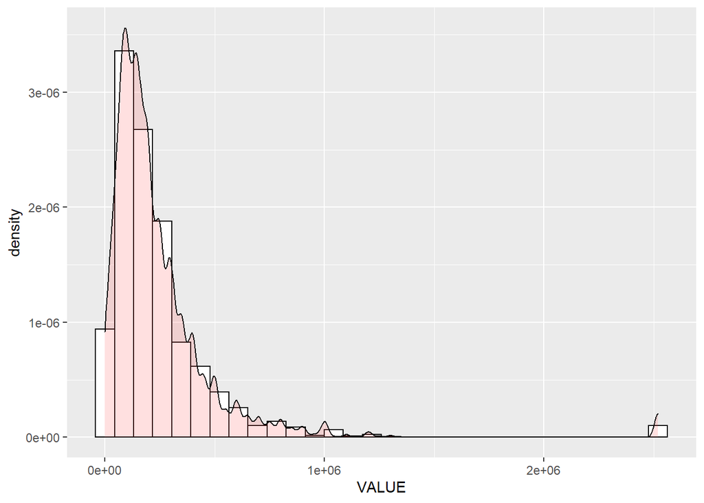

```r
ggplot(had, aes(x=VALUE)) +
  geom_histogram(aes(y=..density..), colour="black", fill="white")+
  geom_density(alpha=.2, fill="#FF6666")
```

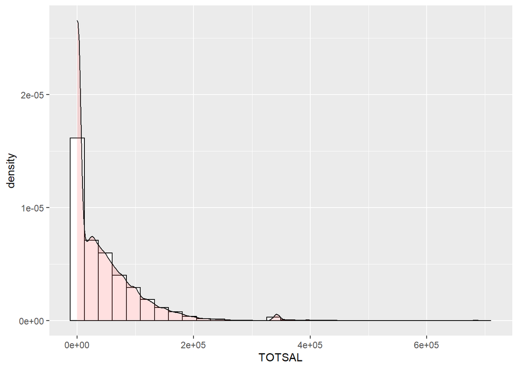

```r
ggplot(had, aes(x=TOTSAL)) +
  geom_histogram(aes(y=stat(density)), colour="black", fill="white")+
  geom_density(alpha=.2, fill="#FF6666")
```

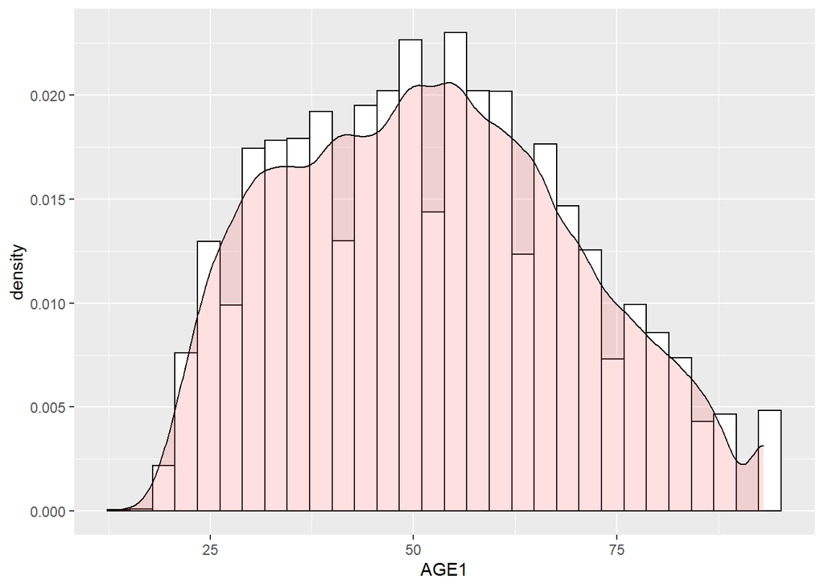

```r
ggplot(had, aes(x=AGE1, color=METRO3)) +
  geom_histogram(aes(y=stat(density)), colour="black", fill="white")+
  geom_density(alpha=.2, fill="#FF6666")
```

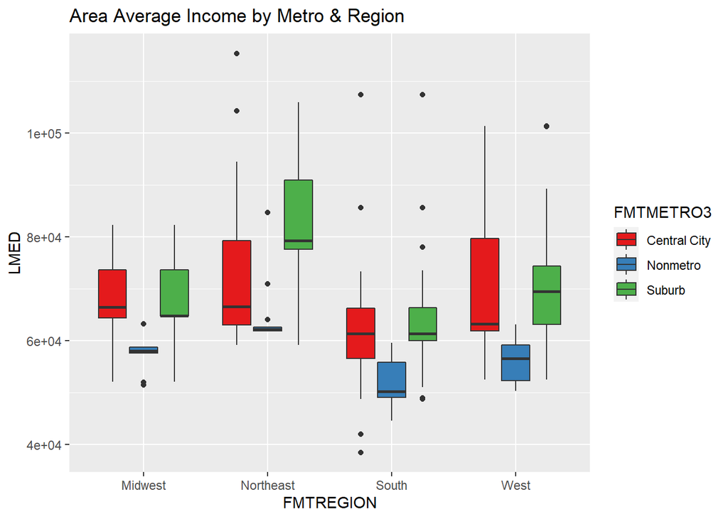

```r
ggplot(had, aes(x=FMTREGION, y=LMED, fill=FMTMETRO3)) +
  geom_boxplot() +
  scale_fill_brewer(palette="Set1") +
  labs(title ="Area Average Income by Metro & Region")
```

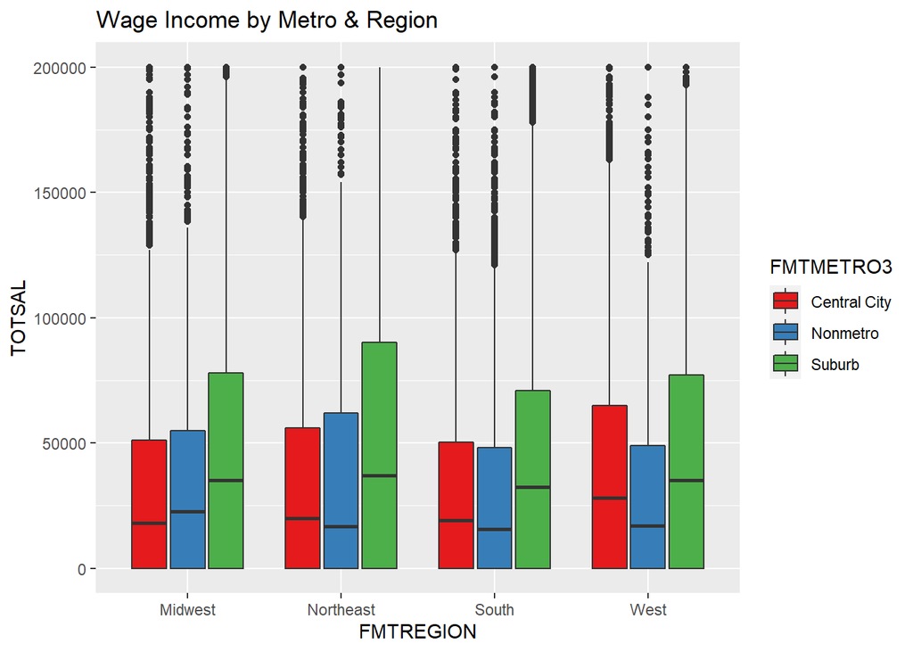

```r
ggplot(had, aes(x=FMTREGION, y=TOTSAL, fill=FMTMETRO3)) +
  geom_boxplot() +
  scale_fill_brewer(palette="Set1") +
  ylim(NA, 2e+05) +
  labs(title ="Wage Income by Metro & Region")
```

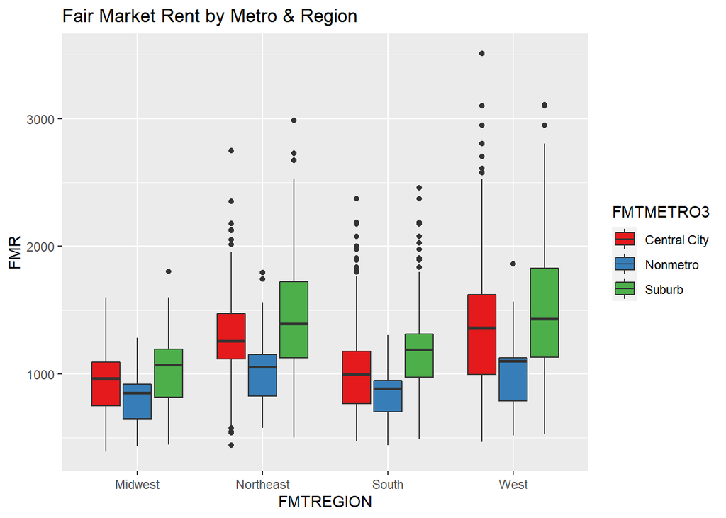

```r
ggplot(had, aes(x=FMTREGION, y=FMR, fill=FMTMETRO3)) +
  geom_boxplot() +
  scale_fill_brewer(palette="Set1") +
  labs(title ="Fair Market Rent by Metro & Region")
```

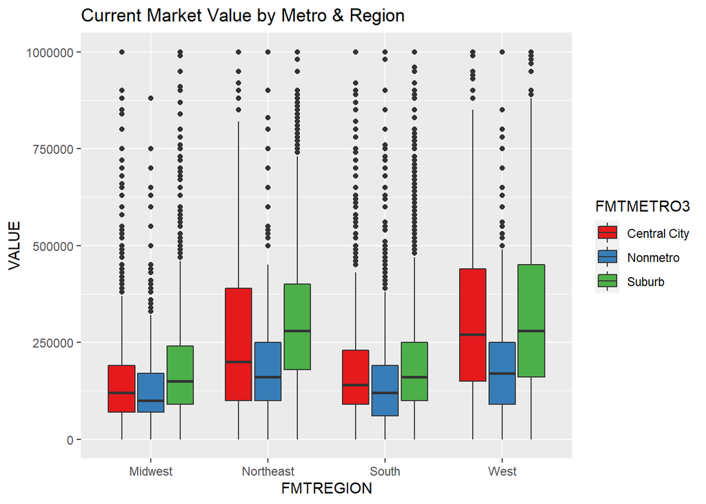

```r
ggplot(had, aes(x=FMTREGION, y=VALUE, fill=FMTMETRO3)) +
  geom_boxplot() +
  scale_fill_brewer(palette="Set1") +
  ylim(NA, 1e+06) +
  labs(title ="Current Market Value by Metro & Region")
```